# 0301

Xinran Miao

3/3/2021

## 1. Read the data.

The California housing dataset includes one dependent variable (`Value`) and 8 explanatory variables. According to `Latitude` and `Longitude`, we split it into source and target, and then split the source dataset into different clusters, and split the target dataset into validation and test. Later we'll use linear regression to predice `Value` with variables except for `Latitude` and `Longitude`.

```r
source('functions0301.R')
library(dplyr)
housing = read.csv('../housing_group.csv')[,-1]
Source = housing[housing$Group == 'Source',]
Validation = housing[housing$Group =='Validation',]
Test = housing[housing$Group == 'Test',]
head(housing)
```

```
##   Value Income Age Population Households Latitude Longitude AvgRooms
## 1 452.6 8.3252  41        322        126    37.88   -122.23 6.984127
## 2 358.5 8.3014  21       2401       1138    37.86   -122.22 6.238137
## 3 352.1 7.2574  52        496        177    37.85   -122.24 8.288136
## 4 341.3 5.6431  52        558        219    37.85   -122.25 5.817352
## 5 342.2 3.8462  52        565        259    37.85   -122.25 6.281853
## 6 269.7 4.0368  52        413        193    37.85   -122.25 4.761658
##   AvgBedrooms      Group Cluster
## 1   1.0238095       Test  Target
## 2   0.9718805       Test  Target
## 3   1.0734463       Test  Target
## 4   1.0730594 Validation  Target
## 5   1.0810811       Test  Target
## 6   1.1036269       Test  Target
```

According to the distance between one cluster and the target, the clusters are ranked as: 3, 1, 2, 4.

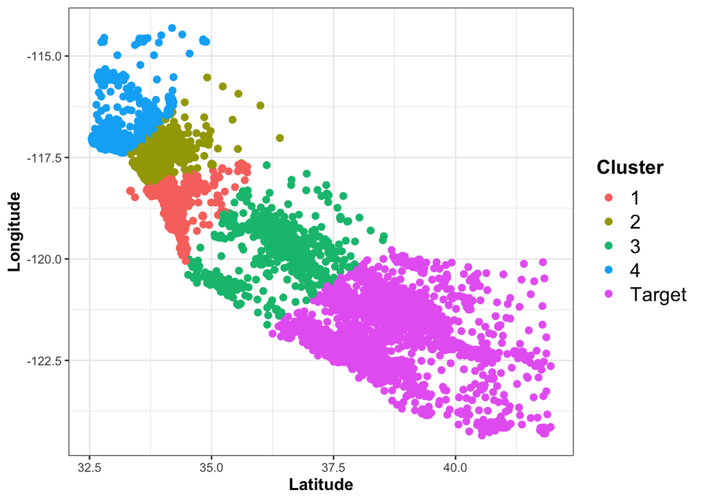

```r
library(ggplot2)
ggplot(housing) +
  geom_point(aes(x = Latitude, y = Longitude, color = Cluster),size = 2) +
  theme_bw()+
  theme(legend.text =element_text(size=14) ,
        legend.title = element_text(size=14,face = 'bold'),
        axis.title = element_text(size=12,face = 'bold'))
```

## 2. Smart Selection & Random Selection.

In the beginning, we random select 100 points from the source.

```r
idx_initial = sample(1:nrow(Source), 100)
MSE_initial = pred_func(Source[,-c(6,7,10,11)], idx_initial , Validation[,-c(6,7,10,11)]); MSE_initial
```

```
## [1] 6801.477
```

For different seeds, we select the samples either smartly or randomly. There are 500 rounds in total. At each round, 10 samples are added to the training set, and the model is evaluated on the validation set.

```r
layout(matrix(1:6,nrow = 3,byrow = TRUE))
for(seed in 1:6){
    step = 10
    l = selection(T = 500,st = 1,step = step, s = seed,
                  compare = 'previous',Source,Validation,idx_initial)
    p_selection(l$MSE,l$MSE_random,l$Clusters,n_cluster = n_cluster,
                  ylim = range(c(range(l$MSE),range(l$MSE_random))),
                  title = paste0('seed = ',seed ,',step = ',step
                                 ))
}
```

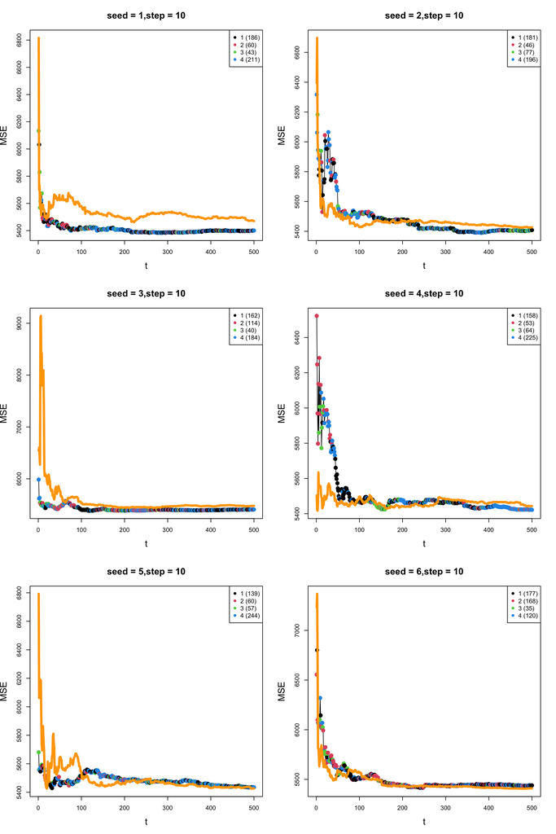

## 3. Take a closer look for seed == 7.

```r
seed = 7
set.seed(seed)
```

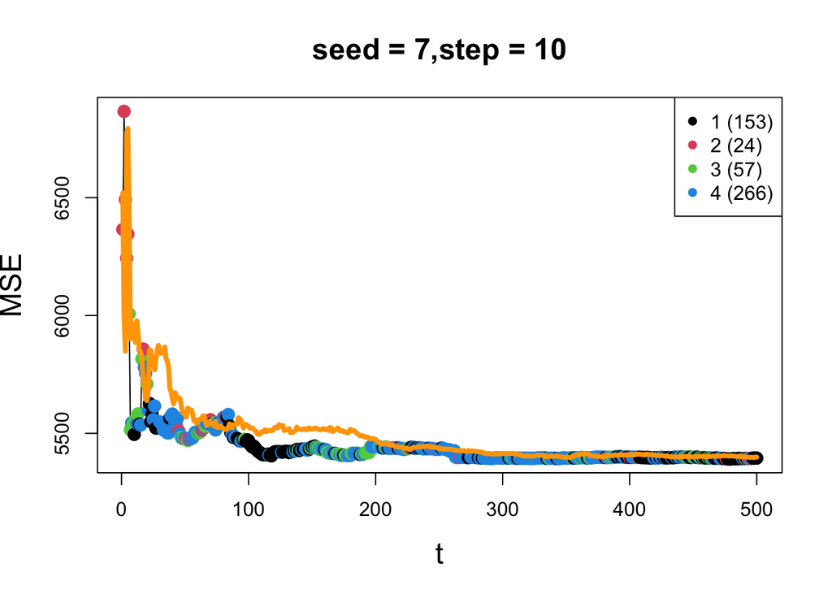

```r
step = 10
l = selection(T = 500,st = 1,step = step, s = seed,compare = 'previous',Source = Source, Validation = Validation,idx_initial = idx_initial)
p_selection(l$MSE,l$MSE_random,l$Clusters,n_cluster = 4,
              ylim = range(c(range(l$MSE),range(l$MSE_random))),
              title = paste0('seed = ',seed ,',step = ',step
              ))
```

```r
pred_func(Source[,-c(6,7,10,11)],l$idx[[500]],
                              Test[,-c(6,7,10,11)])
```

```
## [1] 6043.253
```

```r
pred_func(Source[,-c(6,7,10,11)],l$idx_random[[500]],
                              Test[,-c(6,7,10,11)])
```

```
## [1] 6028.507
```

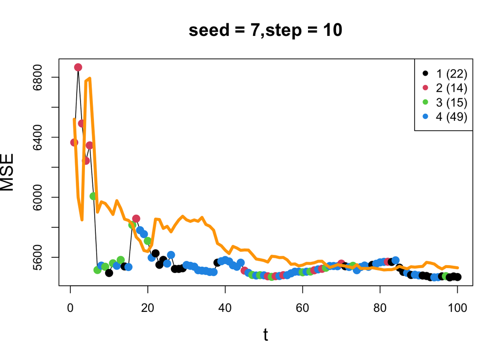

```r
n = 100
p_selection(l$MSE[1:n],l$MSE_random[1:n],l$Clusters[1:n],n_cluster = n_cluster,
              ylim = range(c(range(l$MSE[1:n]),range(l$MSE_random[1:n]))),
              title = paste0('seed = ',seed ,',step = ',step
              ))
```

Is the difference between performance caused by the fact that "Smart selection uses less observations (with some have large weights)"?

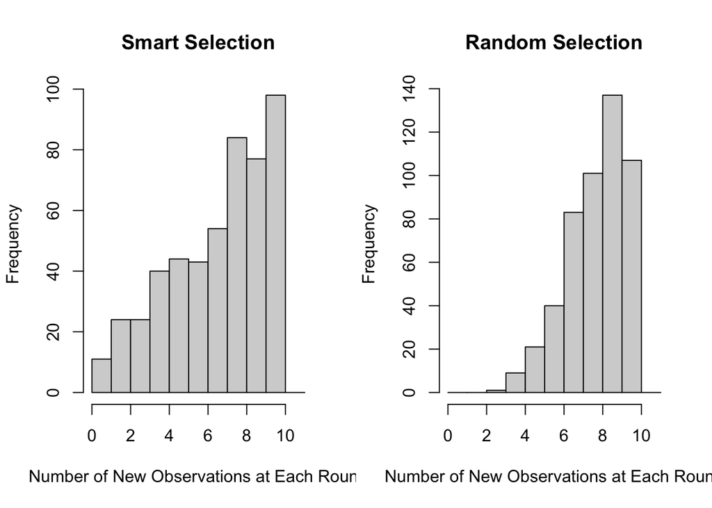

```r
get_difference = function(lst){
  sapply(2:length(lst), function(i){
    setdiff(lst[[i]],lst[[i-1]]) %>% length
  }) %>% unlist
}

layout(matrix(1:2,nrow=1))
hist(get_difference(l$idx),main = 'Smart Selection',xlab = 'Number of New Observations at Each Round',breaks = seq(0,11,1))
hist(get_difference(l$idx_random),main = 'Random Selection',xlab = 'Number of New Observations at Each Round',breaks = seq(0,11,1))
```

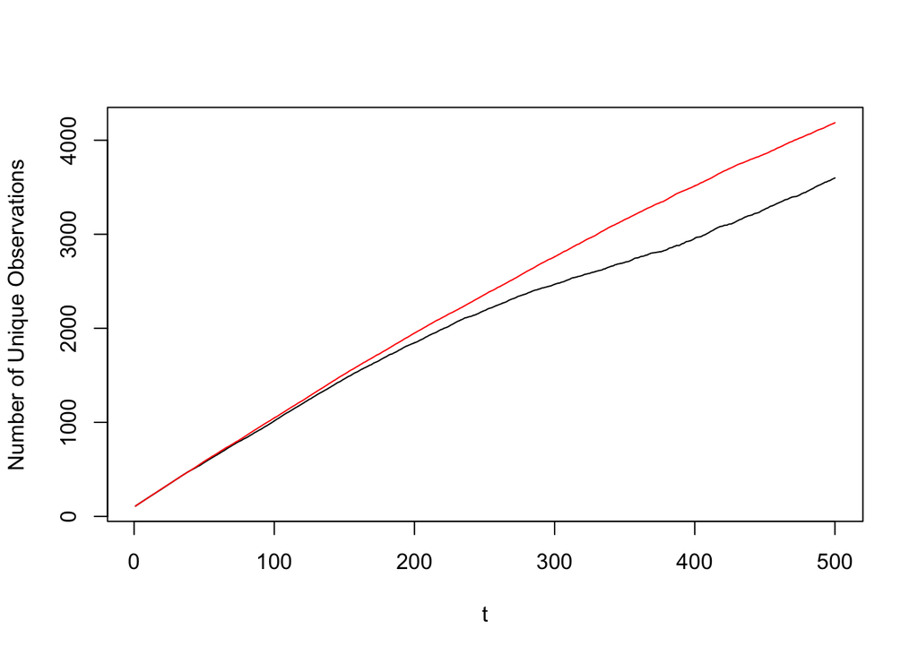

```r
len1 = lapply(l$idx, function(x){x %>% unique() %>% length}) %>% unlist
len2 = lapply(l$idx_random, function(x){x %>% unique() %>% length}) %>% unlist
plot(1:length(l$idx),len1,type = 'l', xlab = 't',ylab = 'Number of Unique Observations',ylim = range(len2))
lines(1:length(l$idx),len2,col = 'red')
```

## What if we use one cluster only?

4 > 2 > 1 > 3

```r
MSE_clst = rep(1,4)
for (clst in 1:4) {
  indices = which(Source$Cluster == clst)
  MSE_clst[clst] = pred_func(Source[,-c(6,7,10,11)],indices,
            Validation[,-c(6,7,10,11)])
}
MSE_clst
```

```
## [1]  9088.020  6521.227 14579.246  5607.338
```

What if we use the closest ones at each round using the same number of **unique** observations with smart selection?

```r
med = c(median(Source$Latitude),median(Source$Longitude))
med
```

```
## [1]   34.01 -118.15
```

```r
distance = apply(Source[,c('Latitude','Longitude')], 1, function(x){
  sqrt((x[1] - med[1])^2 + (x[2] - med[2])^2)
})
```

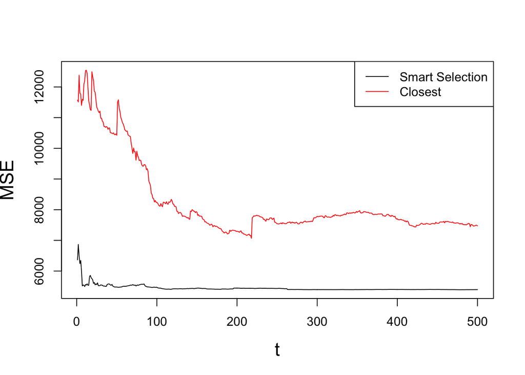

```r
MSE_closest = c()
closest_indices = list()
for(t in 1:500){
  indices = len1[t]
  closest_indices[[t]] = order(distance)[1:indices]

  loss = pred_func(Source[,-c(6,7,10,11)],closest_indices[[t]],
                              Validation[,-c(6,7,10,11)])

  MSE_closest = c(MSE_closest,loss)
}
plot(1:length(l$MSE),l$MSE,type = 'l',xlab = 't',ylab = 'MSE',cex.axis = 1,   cex.lab = 1.5,cex.main = 1.5,
       ylim = range(c(range(l$MSE),range(MSE_closest))) )
lines(1:length(MSE_closest),MSE_closest,col = 'red')
legend('topright',legend = c("Smart Selection","Closest"), lty = c(1,1),col = c('black','red'))
```

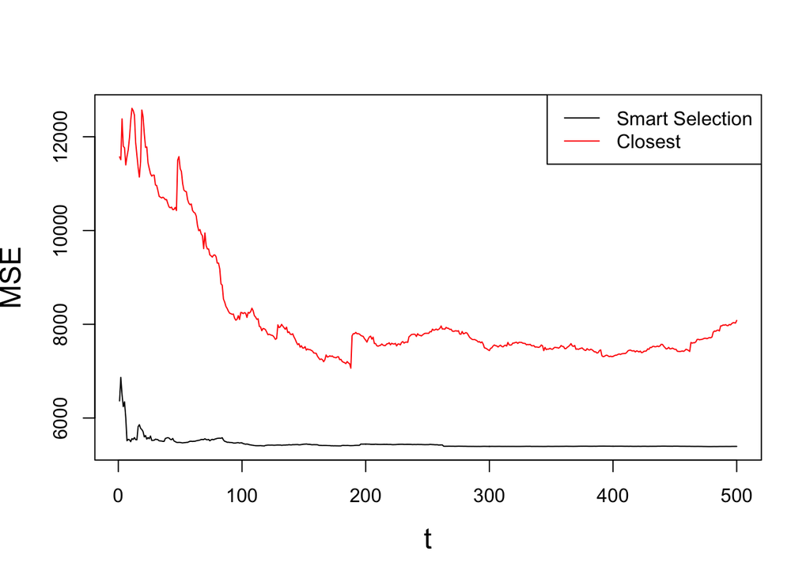

```r
MSE_closest2 = c()
closest_indices2 = list()
for(t in 1:500){
  indices = length(l$idx[[t]])
  closest_indices2[[t]] = order(distance)[1:indices]

  loss = pred_func(Source[,-c(6,7,10,11)],closest_indices2[[t]],
                              Validation[,-c(6,7,10,11)])

  MSE_closest2 = c(MSE_closest2,loss)
}
plot(1:length(l$MSE),l$MSE,type = 'l',xlab = 't',ylab = 'MSE',cex.axis = 1,   cex.lab = 1.5,cex.main = 1.5,
       ylim = range(c(range(l$MSE),range(MSE_closest2))) )
lines(1:length(MSE_closest2),MSE_closest2,col = 'red')
legend('topright',legend = c("Smart Selection","Closest"), lty = c(1,1),col = c('black','red'))
```